# materialxMaterials_tutorial

## Using the materialxMaterials API

To use the API the package can be installed by cloning the repository and then installing it using pip

```python
# pip install .
```

- `GPUOpenMaterialLoader` which can downlad materials from the AMD GPUOpen database
- `PhysicallyBasedMaterialXLoader` which can download materials from the PhysicallyBased database

### 1. GPUOpenMaterialLoader

```python
from materialxMaterials import GPUOpenLoader

loader = GPUOpenLoader.GPUOpenMaterialLoader()

# Download materials
materials = loader.getMaterials()
materialNames = loader.getMaterialNames()
materialCount = len(materialNames)
print(f'Available number of materials: {materialCount}')
```

```
INFO:GPUO:Fetch set of materials: limit: 100 offset: 100
INFO:GPUO:Fetch set of materials: limit: 100 offset: 200
INFO:GPUO:Fetch set of materials: limit: 100 offset: 300
INFO:GPUO:Fetch set of materials: limit: 100 offset: 400
```

```
Available number of materials: 454
```

#### Downloading Material Packages

A regular expression can be used to search for materials. The search is case insensitive and the regular expression is applied to the material name.

The `downloadPackageByExpression()` method is used below to download all materials that contain the word "Canyon Maple Dark Wood" in their name.

The second argument specifies the package number. Different packages have different resolution images. We use `0` to get the first package.

```python
searchExpr = 'Canyon Maple Dark Wood'
dataItems = loader.downloadPackageByExpression(searchExpr, 0)
data = None
for dataItem in dataItems:
    print('Found material: ', dataItem[1])
    data = dataItem[0]
    title = dataItem[1]

if not data:
    print(f'No material found for search expression: {searchExpr}')
```

```
INFO:GPUO:> Download material: Canyon Maple Dark Wood List: 0. Index: 89
```

```
Found material:  Canyon Maple Dark Wood
```

The `downloadPackageByExpression()` method returns a list of material data. The data is in the form of a zip file from which data can be extracted.

In the sample code, the MaterialX file and the images are extracted from the zip file. Image extraction requires passing over the `pillow` module.

```
Issues found:
- Canyon_Maple_Dark_Wood.mtlx is not uncompressed (ZIP_STORED). ZIP_DEFLATED found.
- textures/Canyon_Maple_Dark_Wood_Mask.png is not uncompressed (ZIP_STORED). ZIP_DEFLATED found.
- textures/Canyon_Maple_Dark_Wood_Normal.png is not uncompressed (ZIP_STORED). ZIP_DEFLATED found.
- textures/Canyon_Maple_Dark_Wood_baseColor.png is not uncompressed (ZIP_STORED). ZIP_DEFLATED found.
- MaterialX file Canyon_Maple_Dark_Wood.mtlx
- Image file textures/Canyon_Maple_Dark_Wood_Mask.png
```

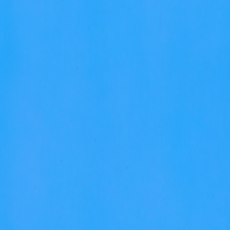

```
- Image file textures/Canyon_Maple_Dark_Wood_Normal.png
```

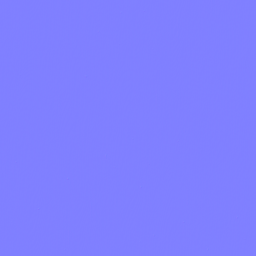

```
- Image file textures/Canyon_Maple_Dark_Wood_baseColor.png
```

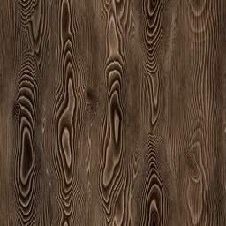

```python
import io
import zipfile
from PIL import Image
from IPython.display import display

issues = loader.check_usdz_image_restrictions(data, Image)
if issues:
    print('Issues found:')
    for issue in issues:
        print(f'- {issue}')
else:
    print('No issues found.')

extracted_data = loader.extractPackageData(data, Image)
if extracted_data:
    for item in extracted_data:
        if item['type'] == 'mtlx':
            print(f'- MaterialX file {item["file_name"]}')
        elif item["type"] == 'image':
            print(f'- Image file {item["file_name"]}')
            image = item["data"]
            small_image = image.resize((256, 256))  # Resize to 256x256 pixels
            display(small_image)
            #display(image)
```

```python
indices = [0, 2, 0]
materialList = int(indices[0])
materialIndex = int(indices[1])
materialPackage = int(indices[2])
[data, title, url] = loader.downloadPackage(materialList, materialIndex, materialPackage)

print(f'Downloaded {title}')
extracted_data = loader.extractPackageData(data, None)
if extracted_data:
    for item in extracted_data:
        if item['type'] == 'mtlx':
            print(f'- MaterialX file {item["file_name"]}')
        elif item["type"] == 'image':
            print(f'- Image file {item["file_name"]}')
```

```
Downloaded Art Deco Gatsby Wallpaper
- MaterialX file Art_Deco_Gatsby_Wallpaper.mtlx
- Image file textures/Art_Deco_Gatsby_Wallpaper_Mask.png
- Image file textures/Art_Deco_Gatsby_Wallpaper_baseColor.png
- Image file textures/Art_Deco_Gatsby_Wallpaper_Normal.png
```

### 2. PhysicallyBasedMaterialXLoader

The `PhysicallyBasedMaterialXLoader` has a dependence on MaterialX to generate MaterialX documents from the material descriptions downloaded from the PhysicallyBased database.

The material information can first be downloaded using `getMaterialsFromURL()` method. The method returns a list of material data in JSON format

```python
from materialxMaterials import physicallyBasedMaterialX as pbmx
import MaterialX as mx

jsonMat = None
pb_loader = pbmx.PhysicallyBasedMaterialLoader(mx, None)
jsonMat = pb_loader.getMaterialsFromURL()
print(f'Found {len(jsonMat)} materials in PhysicallyBased MaterialX library.')

# Print JSON formatted
#import json
#print(json.dumps(jsonMat, indent=4))
```

```
INFO:PBMXLoader:> Load remapping from installed package: PhysicallyBasedMaterialX/PhysicallyBasedToMtlxMappings.json
INFO:PBMXLoader:> Created Physically Based MaterialX definition library...
INFO:PBMXLoader:> Definition documents passed validation.
INFO:PBMXLoader:> Created translator to BSDF: gltf_pbr
INFO:PBMXLoader:> Created translator to BSDF: open_pbr_surface
INFO:PBMXLoader:> Created translator to BSDF: standard_surface
WARNING:PBMXLoader:> Translator NodeDef already exists: ND_standard_surface_surfaceshader_100
INFO:PBMXLoader:> Created translator to BSDF: standard_surface
```

```
Found 110 materials in PhysicallyBased MaterialX library.
```

This data can be parsed to create MaterialX documents using the `convertToMaterialX()` method. One of the supported shading models can be used. In the example below we convert to the `OpenPBR` model. We set a postfix string to make a unique id.

```python
# Convert to OpenPBR material
#pb_loader.convertToMaterialX(['Banana'], 'open_pbr_surface', {}, 'OpenPBR')
#matdoc_string = pb_loader.convertToMaterialXString()
#print(matdoc_string)
```

In this example we generate `glTF` PBR materials instead.

```python
pb_loader.convertToMaterialX(['Banana'], 'gltf_pbr', {}, 'glTF')
matdoc_string = pb_loader.convertToMaterialXString()
print(matdoc_string)
```

```
<?xml version="1.0"?>
<materialx version="1.39">
  <!--Physically Based Materials from https://api.physicallybased.info -->
  <!--  Content Author: Anton Palmqvist, https://antonpalmqvist.com/ -->
  <!--  Content processsed via REST API and mapped to MaterialX V1.39.5 -->
  <!--  Target Shading Model: gltf_pbr -->
  <!--  Utility Author: Bernard Kwok. kwokcb@gmail.com -->
  <!-- Generated shader: Banana_glTF_SHD_PBM -->
  <gltf_pbr name="Banana_glTF_SHD_PBM" type="surfaceshader" uiname="Banana" uifolder="Organic" doc="Reference: https://raw.githubusercontent.com/AntonPalmqvist/physically-based-api/main/images/renders/cycles/300/banana.avif">
    <input name="base_color" type="color3" value="0.634, 0.532, 0.111" colorspace="lin_rec709" />
    <input name="metallic" type="float" value="0" />
    <input name="roughness" type="float" value="0.5" />
    <input name="ior" type="float" value="1.5" />
  </gltf_pbr>
  <!-- Generated material: Banana_glTF_MAT_PBM -->
  <surfacematerial name="Banana_glTF_MAT_PBM" type="material">
    <input name="surfaceshader" type="surfaceshader" nodename="Banana_glTF_SHD_PBM" />
  </surfacematerial>
</materialx>
```

### 3. AmbientCGLoader

The `AmbientCGLoader` allows you to download and extract materials from the [ambientCG](https://ambientcg.com/) database.

In the first example we create a loader and download the list of available materials.

```python
from materialxMaterials import ambientCGLoader
import MaterialX as mx

# Create the loader
loader = ambientCGLoader.AmbientCGLoader(mx, None)

# Download the list of available materials
materials = loader.downloadMaterialsList()
materialNames = loader.getMaterialNames()
materialCount = len(materialNames)
print(f'Found {materialCount} materials in AmbientCG library')
```

```
INFO:ACGLoader:Using MaterialX version: 1.39.5
INFO:ACGLoader:Downloading materials CSV list...
INFO:ACGLoader:Downloaded CSV material list as JSON.
```

```
Found 1994 materials in AmbientCG library
```

#### Downloading Material Packages

Once we have a list we can search for a specific material name. In this case we look for the first occurance of `WoodFloor038`. We specify the format to download and the image resolition. "1" resolution means 1K image files.

```python
materialName = 'WoodFloor038'
result = loader.findMaterial(materialName)
if result:
    fileName = loader.downloadMaterialAsset(materialName) #, opts.downloadmageFormat, opts.downloadResolution)
    if len(fileName) > 0:
        loader.writeDownloadedMaterialToFile('.')
```

```
INFO:ACGLoader:Found Asset: WoodFloor038. Download Attribute: 1K-PNG -> https://ambientCG.com/get?file=WoodFloor038_1K-PNG.zip
INFO:ACGLoader:Material file downloaded: WoodFloor038_1K-PNG.zip
INFO:ACGLoader:Saved downloaded material to: .\WoodFloor038_1K-PNG.zip
```

```
Extracting data from zip file: WoodFloor038_1K-PNG.zip
- Image file WoodFloor038_1K-PNG_AmbientOcclusion.png
```

[figure not shown]

```
- Image file WoodFloor038_1K-PNG_Color.png
```

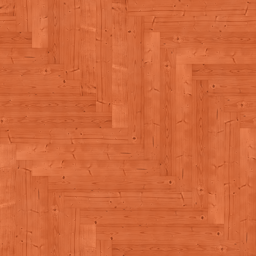

```
- Image file WoodFloor038_1K-PNG_Displacement.png
```

```
- Image file WoodFloor038_1K-PNG_NormalDX.png
```

[figure not shown]

```
- Image file WoodFloor038_1K-PNG_NormalGL.png
```

[figure not shown]

```
- Image file WoodFloor038_1K-PNG_Roughness.png
```

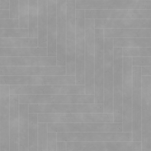

```
- MaterialX file WoodFloor038_1K-PNG.mtlx
- Image file WoodFloor038.png
```

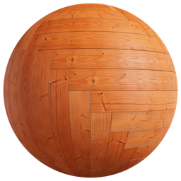

```python
import io
import zipfile
from PIL import Image
from IPython.display import display

def extractPackageData(data, pilImage):
    '''
    Extract the package data from a zip file.
    @param data: The data to extract.
    @param pilImage: The PIL image module.
    @return: A list of extracted data of the form:
    [ { 'file_name': file_name, 'data': data, 'type': type } ]
    '''
    if not pilImage:
        pilImage = PILImage
    if not pilImage:
        self.logger.debug('Pillow (PIL) image module provided. Image data will not be extracted.')

    #zip_object = io.BytesIO(data)

    extracted_data_list = []
    with zipfile.ZipFile(data, 'r') as zip_file:
        # Iterate through the files in the zip archive
        for file_name in zip_file.namelist():
            # Extract each file into memory
            extracted_data = zip_file.read(file_name)
            if file_name.endswith('.mtlx'):
                mtlx_string = extracted_data.decode('utf-8')
                extracted_data_list.append( {'file_name': file_name, 'data': mtlx_string, 'type': 'mtlx'} )

            # If the data is a image, create a image in Python
            elif file_name.endswith('.png'):
                if pilImage:
                    image = pilImage.open(io.BytesIO(extracted_data))
                else:
                    image = None
                extracted_data_list.append( {'file_name': file_name, 'data': image, 'type': 'image'} )

    return extracted_data_list

# Extract and display MaterialX and image files from the downloaded zip
if fileName:
    with open(fileName, 'rb') as f:
        data = io.BytesIO(f.read())

    if data:
        print(f'Extracting data from zip file: {fileName}')
        extracted_data = extractPackageData(data, Image)
        if extracted_data:
            for item in extracted_data:
                if item['type'] == 'mtlx':
                    print(f'- MaterialX file {item["file_name"]}')
                elif item['type'] == 'image':
                    print(f'- Image file {item["file_name"]}')
                    image = item['data']
                    small_image = image.resize((256, 256))  # Resize to 256x256 pixels
                    display(small_image)

# Delete the unzipped folder and the zip file
import shutil
import os
#shutil.rmtree(os.path.splitext(fileName)[0], ignore_errors=True)
os.remove(fileName)
```

### 4. PolyHavenLoader

The `PolyHavenLoader` allows you to download and extract materials from the [Poly Haven](https://polyhaven.com/) database. This loader provides access to a wide variety of high-quality, free textures and materials.

Below is an example of how to use the loader to search for and download a material package.

```python
# PolyHavenLoader usage example (following polyHavenLoaderCmd.py logic)
from pathlib import Path
import json
from materialxMaterials import polyHavenLoader
import os
import zipfile
import io
from PIL import Image
from IPython.display import display
import shutil

# Set download parameters
download_id = "polystyrene"
#download_id = "aerial_asphalt_01"
resolution = "1k"            # Specify resolution: '1k', '2k', '4k', or '8k'
data_folder = "data/PolyHavenMaterialX"
os.makedirs(data_folder, exist_ok=True)
max_items = 1

# Fetch MaterialX assets list
loader = polyHavenLoader.PolyHavenLoader()
if loader:
    download_types = ['mtlx'] #, 'blend', 'gltf']

    for download_type in download_types:
        materialx_assets, all_assets, \
            filtered_polyhaven_assets, blender_assets, gltf_assets = \
                loader.fetch_materialx_assets(max_items=max_items, download_id=download_id, download_type=download_type)

        #materialx_assets, all_assets, filtered_polyhaven_assets = loader.fetch_materialx_assets(download_id=download_id)
        print(f'Found {len(materialx_assets)} matching assets.')

        #print(materialx_assets)
        for entry_id, entry in materialx_assets.items():
            print(f'- {entry_id}: {entry}')

        # Save list to file
        #data_file = Path(data_folder) / "polyhaven_materialx_assets.json"
        #with open(data_file, "w") as f:
        #    json.dump(materialx_assets, f, indent=4)

        # Download the material (zip file)
        entry_id = download_id + '_' + resolution
        print('\nLook for entry_id:', entry_id)
        entry = materialx_assets.get(entry_id)
        if entry:
            asset_list = {entry_id: entry, resolution: resolution}
            if asset_list:
                id, mtlx_string, texture_binaries = loader.download_mtlx_asset(asset_list)
                loader.save_materialx_with_textures(id, mtlx_string, texture_binaries, data_folder)
                print(f'Downloaded "{download_id}" material to: {data_folder}/{id}_materialx.zip')
        else:
            print(f'Error: Material "{download_id}" with resolution "{resolution}" not found in PolyHaven library.')
```

```
INFO:PolyH:Id: 'polystyrene' has blender: True, glTF: True, mtlx: True
INFO:PolyH:Download MaterialX document https://dl.polyhaven.org/file/ph-assets/Textures/mtlx/1k/polystyrene/polystyrene_1k.mtlx, length: 4690 characters
```

```
Found 4 matching assets.
- polystyrene_1k: {'url': 'https://dl.polyhaven.org/file/ph-assets/Textures/mtlx/1k/polystyrene/polystyrene_1k.mtlx', 'texture_files': {'textures/polystyrene_rough_1k.exr': 'https://dl.polyhaven.org/file/ph-assets/Textures/exr/1k/polystyrene/polystyrene_rough_1k.exr', 'textures/polystyrene_disp_1k.p…
- polystyrene_2k: {'url': 'https://dl.polyhaven.org/file/ph-assets/Textures/mtlx/2k/polystyrene/polystyrene_2k.mtlx', 'texture_files': {'textures/polystyrene_diff_2k.jpg': 'https://dl.polyhaven.org/file/ph-assets/Textures/jpg/2k/polystyrene/polystyrene_diff_2k.jpg', 'textures/polystyrene_rough_2k.ex…
- polystyrene_4k: {'url': 'https://dl.polyhaven.org/file/ph-assets/Textures/mtlx/4k/polystyrene/polystyrene_4k.mtlx', 'texture_files': {'textures/polystyrene_nor_gl_4k.exr': 'https://dl.polyhaven.org/file/ph-assets/Textures/exr/4k/polystyrene/polystyrene_nor_gl_4k.exr', 'textures/polystyrene_diff_4k…
- polystyrene_8k: {'url': 'https://dl.polyhaven.org/file/ph-assets/Textures/mtlx/8k/polystyrene/polystyrene_8k.mtlx', 'texture_files': {'textures/polystyrene_diff_8k.jpg': 'https://dl.polyhaven.org/file/ph-assets/Textures/jpg/8k/polystyrene/polystyrene_diff_8k.jpg', 'textures/polystyrene_nor_gl_8k.e…

Look for entry_id: polystyrene_1k
```

```
INFO:PolyH:Download https://dl.polyhaven.org/file/ph-assets/Textures/png/1k/polystyrene/polystyrene_rough_1k.png instead of https://dl.polyhaven.org/file/ph-assets/Textures/exr/1k/polystyrene/polystyrene_rough_1k.exr SUCCESSFUL
INFO:PolyH:- Updating texture path from textures/polystyrene_rough_1k.exr to textures\polystyrene_rough_1k.png
INFO:PolyH:Download texture from https://dl.polyhaven.org/file/ph-assets/Textures/png/1k/polystyrene/polystyrene_disp_1k.png ...
INFO:PolyH:Download texture from https://dl.polyhaven.org/file/ph-assets/Textures/jpg/1k/polystyrene/polystyrene_diff_1k.jpg ...
INFO:PolyH:Download https://dl.polyhaven.org/file/ph-assets/Textures/png/1k/polystyrene/polystyrene_nor_gl_1k.png instead of https://dl.polyhaven.org/file/ph-assets/Textures/exr/1k/polystyrene/polystyrene_nor_gl_1k.exr SUCCESSFUL
INFO:PolyH:- Updating texture path from textures/polystyrene_nor_gl_1k.exr to textures\polystyrene_nor_gl_1k.png
INFO:PolyH:Download thumbnail from https://cdn.polyhaven.com/asset_img/thumbs/polystyrene.png?width=256&height=256 ...
INFO:PolyH:Updated MaterialX string to reference PNG texture instead of EXR for textures\polystyrene_nor_gl_1k.png
INFO:PolyH:Saved zip: data\PolyHavenMaterialX\polystyrene_1k_materialx.zip
```

```
Downloaded "polystyrene" material to: data/PolyHavenMaterialX/polystyrene_1k_materialx.zip
```

After downloading, we can again unzip the contents and display them here.

```
Extract contents of zip file: data\PolyHavenMaterialX\polystyrene_1k_materialx.zip

- MaterialX file: polystyrene_1k.mtlx
<?xml version="1.0"?>
<materialx version="1.39">
  <nodegraph name="NG_polystyrene">
    <texcoord name="Texcoord" type="vector2">
      <input name="index" type="integer" value="0" />
    </texcoord>
    <image name="diff" type="color3">
      <input name="file" type="filename" value="textures/polystyrene_diff_1k.jpg" colorspace="srgb_texture" />
      <input name="default" type="color3" value="0.8, 0.6, 0.4" />
      <input name="texcoord" type="vector2" nodename="Texcoord" />
    </image>
    <image name="rough" type="float">
      <input name="file" type="filename" value="textures/polystyrene_rough_1k.png" />
      <input name="default" type="float" value="0.3" />
      <input name="texcoord" type="vector2" nodename="Texcoord" />
    </image>
    <image name="normal" type="vector3">
      <input name="file" type="filename" value="textures/polystyrene_nor_gl_1k.png" />
      <input name="default" type="vector3" value="0.5, 0.5, 1" />
      <input name="texcoord" type="vector2" nodename="Texcoord" />
    </image>
    <normalmap name="Normalmap" type="vector3">
      <input name="in" type="vector3" nodename="normal" />
      <input name="scale" type="float" value="1" />
    </normalmap>
    <tangent name="Tangent" type="vector3">
      <input name="space" type="string" value="world" />
      <input name="index" type="integer" value="0" />
    </tangent>
    <image name="disp" type="float">
      <input name="file" type="filename" value="textures/polystyrene_disp_1k.png" />
      <input name="default" type="float" value="0" />
      <input name="texcoord" type="vector2" nodename="Texcoord" />
    </image>
    <output name="output_diff_out" type="color3" nodename="diff" />
    <output name="output_rough_out" type="float" nodename="rough" />
    <output name="output_Normalmap_out" type="vector3" nodename="Normalmap" />
```

[output cut: 30 more lines]

```
    <input name="sheen" type="float" value="0" />
    <input name="sheen_color" type="color3" value="1, 1, 1" />
    <input name="sheen_roughness" type="float" value="0.3" />
    <input name="emission" type="float" value="0" />
    <input name="emission_color" type="color3" value="1, 1, 1" />
    <input name="normal" type="vector3" output="output_Normalmap_out" nodegraph="NG_polystyrene" />
    <input name="tangent" type="vector3" output="output_Tangent_out" nodegraph="NG_polystyrene" />
  </standard_surface>
  <surfacematerial name="polystyrene" type="material">
    <input name="surfaceshader" type="surfaceshader" nodename="SR_polystyrene" />
    <input name="displacementshader" type="displacementshader" nodename="Displacement" />
  </surfacematerial>
</materialx>

- Image file: textures/polystyrene_rough_1k.png
```

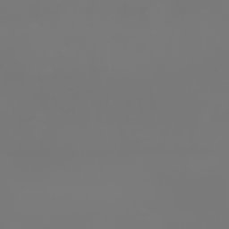

```
- Image file: textures/polystyrene_disp_1k.png
```

```
- Image file: textures/polystyrene_diff_1k.jpg
```

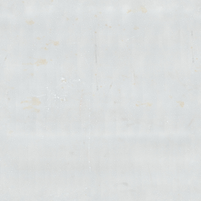

```
- Image file: textures/polystyrene_nor_gl_1k.png
```

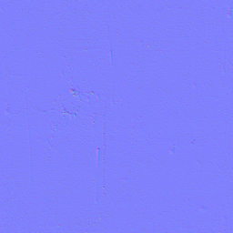

```
- Image file: polystyrene_1k_thumbnail.png
```

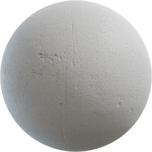

```python
if entry:
    zip_path = Path(data_folder) / f"{id}_materialx.zip"
    print(f'Extract contents of zip file: {zip_path}\n')

    with zipfile.ZipFile(zip_path, 'r') as zip_file:
        for file_name in zip_file.namelist():
            if file_name.endswith('.mtlx'):
                mtlx_doc = zip_file.read(file_name).decode('utf-8')
                print(f'- MaterialX file: {file_name}')
                doc = mx.createDocument()
                mx.readFromXmlString(doc, mtlx_doc)
                mtlx_doc = mx.writeToXmlString(doc)
                print(mtlx_doc)
            elif file_name.endswith('.png') or file_name.endswith('.jpg') or file_name.endswith('.jpeg'):
                image = Image.open(io.BytesIO(zip_file.read(file_name)))
                print(f'- Image file: {file_name}')
                small_image = image.resize((256, 256))
                display(small_image)

    # Clean up
    shutil.rmtree(zip_path.parent, ignore_errors=True)
else:
    print(f"No asset found for ID '{entry_id}'")
```